# Learning novel skills from iconic gestures: A developmental and evolutionary perspective

Supplementary material and analysis

# Overview

Please note that the some values in this document might be different compared to the ones reported in the corresponding manuscript when you choose to run the models yourself. This is a consequence of the way the models are fit. Differences are minor and never affect interpretation of the results. The results reported in the paper can be obtained by lodaing the corresponding `.rds` files.

## Datafile

Variables:

- subject: unique subject id.
- group: 2-, 3-year-olds, 3-year-olds replication or ape species.
- condition: arbitrary or iconic.
- apparatus: apart (app1 in manuscript) and boxing (app2 in manuscript)
- solve: successful box opening.
- sum_part_act: sum of partial actions (not applicable for 3-year-olds and 3-year-olds replication).

Head of data file:

```r
data <- read_csv("../data/ticon_data.csv")

head(data)%>%
  kable()
```

| subject | group | condition | apparatus | solve | sum_part_act |
| --- | --- | --- | --- | --- | --- |
| c752862 | 36mo | arbitrary | apart | 1 | NA |
| c763329 | 36mo | arbitrary | apart | 1 | NA |
| c752859 | 36mo | arbitrary | boxing | 1 | NA |
| c743079 | 36mo | arbitrary | boxing | 1 | NA |
| c741009 | 36mo | arbitrary | boxing | 1 | NA |
| c755592 | 36mo | arbitrary | apart | 0 | NA |

## Proportion of box opening by group and condition.

```r
data %>%
  mutate(group = ifelse (group == "24mo" | group == "36mo" | group == "36mo_replication", group, "ape"))%>%
  group_by(group,condition)%>%
  summarise(n = length(unique(subject)),
            prop_solve = mean(solve))%>%
  kable(digits = 2)
```

| group | condition | n | prop_solve |
| --- | --- | --- | --- |
| 24mo | arbitrary | 18 | 0.33 |
| 24mo | iconic | 18 | 0.39 |
| 36mo | arbitrary | 18 | 0.33 |
| 36mo | iconic | 18 | 0.78 |
| 36mo_replication | arbitrary | 25 | 0.27 |
| 36mo_replication | iconic | 25 | 0.60 |
| ape | arbitrary | 18 | 0.11 |
| ape | iconic | 18 | 0.11 |

## Overview plot (Figure 2 in manuscript)

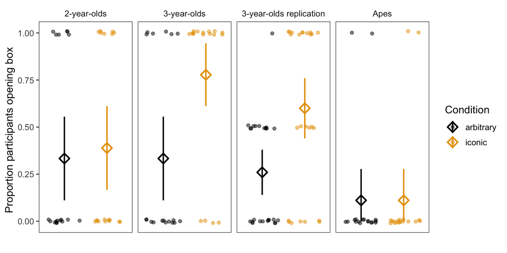

```r
ggsave("../figures/figure2.png", dpi = 500, scale = 1.3, width = 7, height = 3)
```

# Study 1: 2- and 3-year-old children

## Models for box opening including both age groups

- m1child (model 1): `solve ~ group * condition + apparatus`
- m2child (model 2): `solve ~ group + condition + apparatus`
- m3child (model 3): `solve ~ group + apparatus`

```r
## subsetting the data
child_data <- data %>%
  filter(group == "24mo" | group == "36mo")

# model including interaction

# m1child = brm(solve ~
#           group*condition + apparatus,
#         data= child_data,
#         family = bernoulli(),
#         control = list(adapt_delta = 0.90),
#         chains = 4,
#         cores = 4,
#         sample_prior = F,
#         save_all_pars = T,
#         iter = 10000)%>%
#   saveRDS(.,"../saves/m1child.rds")

m1child <- readRDS("../saves/m1child.rds")

# model without interaction

# m2child = brm(solve ~
#           group + condition + apparatus,
#         data= child_data,
#         family = bernoulli(),
#         control = list(adapt_delta = 0.90),
#         sample_prior = F,
#         chains = 4,
#         cores = 4,
#         save_all_pars = T,
#         iter = 10000)%>%
#   saveRDS(.,"../saves/m2child.rds")

m2child <- readRDS("../saves/m2child.rds")

# model without condition

# m3child = brm(solve ~
#           group + apparatus,
#         data= child_data,
#         family = bernoulli(),
#         control = list(adapt_delta = 0.90),
#         sample_prior = F,
#         chains = 4,
#         cores = 4,
#         save_all_pars = T,
#         iter = 10000)%>%
#   saveRDS(.,"../saves/m3child.rds")

m3child <- readRDS("../saves/m3child.rds")
```

### WAIC

```r
child_waic <- brms::WAIC(m1child, m2child,m3child, compare = F)

child_weights <- model_weights(m1child, m2child,m3child, weights = "waic")

data_frame(
  model = c("model 1","model 2","model 3"),
  WAIC = c(child_waic$loo$m1child$estimates[3,1],
           child_waic$loo$m2child$estimates[3,1],
           child_waic$loo$m3child$estimates[3,1]),
  SE = c(child_waic$loo$m1child$estimates[3,2],
         child_waic$loo$m2child$estimates[3,2],
         child_waic$loo$m3child$estimates[3,2]),
  weight = c(child_weights[1],child_weights[2],
             child_weights[3]))%>%
  kable(digits = 2)
```

[output not shown]

```r
fixef(m1child)%>%
  kable(digits = 2)
```

|  | Estimate | Est.Error | Q2.5 | Q97.5 |
| --- | --- | --- | --- | --- |
| Intercept | -0.82 | 0.58 | -1.99 | 0.28 |
| group36mo | 0.00 | 0.73 | -1.44 | 1.44 |
| conditioniconic | 0.26 | 0.72 | -1.16 | 1.70 |
| apparatusboxing | 0.14 | 0.53 | -0.90 | 1.19 |
| group36mo:conditioniconic | 1.86 | 1.08 | -0.25 | 4.03 |

#### Density plots

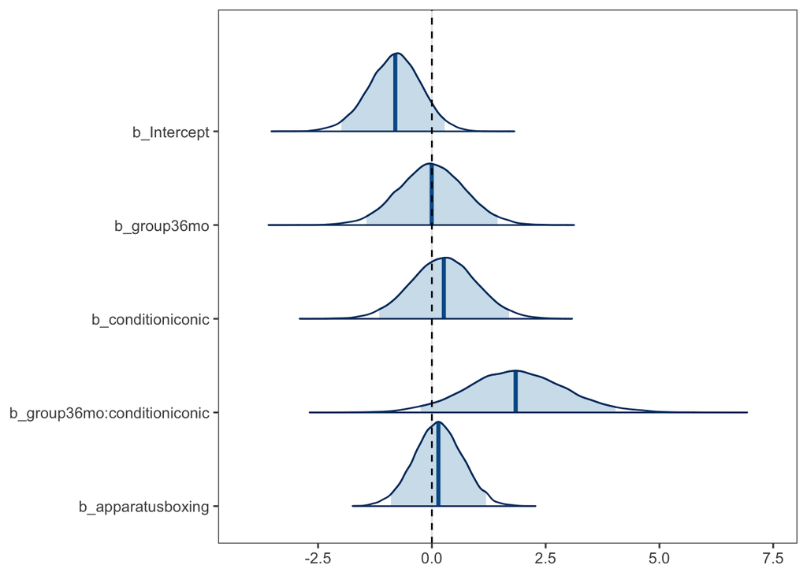

```r
bayesplot::mcmc_areas(as.array(m1child),
                      pars = c("b_Intercept", "b_group36mo", "b_conditioniconic", "b_group36mo:conditioniconic", "b_apparatusboxing"),
                      prob = 0.95)+
  geom_vline(xintercept = 0, lty = 2, col = "black")+
  theme_few()
```

### Summary for model with only main effects (model 2)

```r
fixef(m2child)%>%
  kable(digits = 2)
```

|  | Estimate | Est.Error | Q2.5 | Q97.5 |
| --- | --- | --- | --- | --- |
| Intercept | -1.29 | 0.54 | -2.38 | -0.26 |
| group36mo | 0.91 | 0.51 | -0.09 | 1.94 |
| conditioniconic | 1.14 | 0.52 | 0.14 | 2.18 |
| apparatusboxing | 0.13 | 0.51 | -0.87 | 1.14 |

#### Density plots

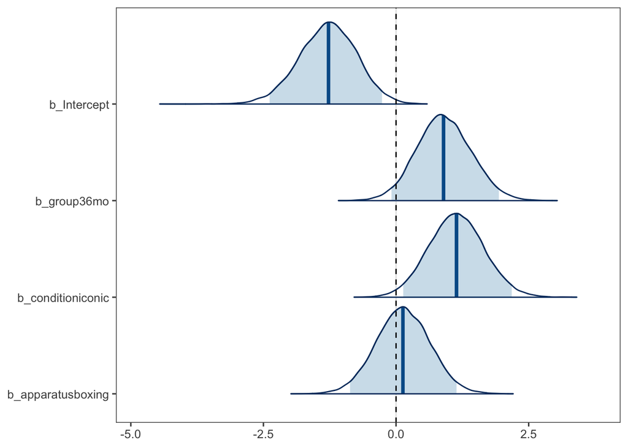

```r
bayesplot::mcmc_areas(as.array(m2child),
                      pars = c("b_Intercept", "b_group36mo", "b_conditioniconic", "b_apparatusboxing"),
                      prob = 0.95)+
  geom_vline(xintercept = 0, lty = 2, col = "black")+
  theme_few()
```

### Figure S1: Comparing posterior predictions based on model 1 and 2

The plot below is based on samples drawn from the posterior distributions for model 1 (including interaction) and model 2 (only main effects).

Black triangles are expected proportions based on model 1, grey stars are based on model 2. Error bars are 95% intervals of extracted samples. Colored diamonds are condition means based on the data.

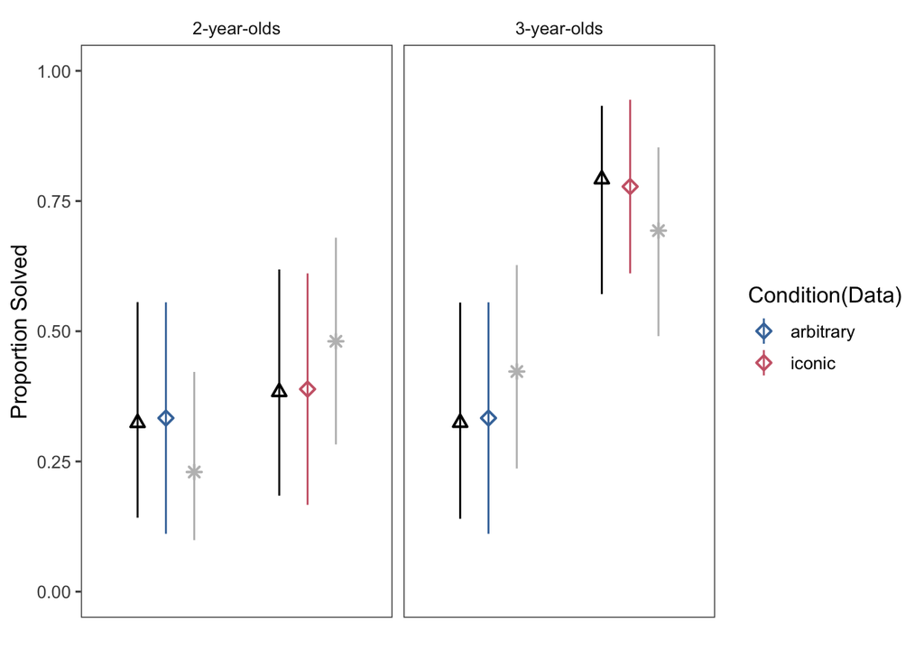

## Models for box opening by age group

```r
# subsetting data
data_24 <- data %>%
  filter(group == "24mo")

# subsetting data
data_36 <- data %>%
  filter(group == "36mo")

# model with condition 24 mo
# m1_24 = brm(solve ~
#           condition + apparatus,
#         data= data_24,
#         family = bernoulli(),
#         control = list(adapt_delta = 0.90),
#         sample_prior = F,
#         save_all_pars = T,
#         chains = 4,
#         cores = 4,
#         iter = 10000)%>%
#   saveRDS(.,"../saves/m1_24.rds")

m1_24 <- readRDS("../saves/m1_24.rds")

# model without condition 24 mo
# m2_24 = brm(solve ~
#           apparatus,
#         data= data_24,
#         family = bernoulli(),
#         control = list(adapt_delta = 0.90),
#         sample_prior = F,
#         save_all_pars = T,
#         chains = 4,
#         cores = 4,
#         iter = 10000)%>%
#   saveRDS(.,"../saves/m2_24.rds")

m2_24 <- readRDS("../saves/m2_24.rds")

# model with condition 36 mo
# m1_36 = brm(solve ~
#           condition + apparatus,
#         data= data_36,
#         family = bernoulli(),
#         control = list(adapt_delta = 0.90),
#         sample_prior = F,
#         save_all_pars = T,
#         chains = 4,
#         cores = 4,
#         iter = 10000)%>%
#   saveRDS(.,"../saves/m1_36.rds")

m1_36 <- readRDS("../saves/m1_36.rds")

# model without condition 36 mo
# m2_36 = brm(solve ~
#           apparatus,
#         data= data_36,
#         family = bernoulli(),
#         control = list(adapt_delta = 0.90),
#         sample_prior = F,
#         save_all_pars = T,
#         chains = 4,
#         cores = 4,
#         iter = 10000)%>%
#   saveRDS(.,"../saves/m2_36.rds")

m2_36 <- readRDS("../saves/m2_36.rds")
```

### 2-year-olds

#### WAIC

```r
waic_24mo <- brms::WAIC(m1_24,m2_24, compare = F)

weights_24mo <- model_weights(m1_24, m2_24, weights = "waic")

data_frame(
  model = c("model w/ condition","model w/o conditon"),
  WAIC = c(
    waic_24mo$loo$m1_24$estimates[3,1],
    waic_24mo$loo$m2_24$estimates[3,1]),
  SE = c(waic_24mo$loo$m1_24$estimates[3,2],
         waic_24mo$loo$m2_24$estimates[3,2]),
  weight = c(weights_24mo[1],
             weights_24mo[2]))%>%
  kable(digits = 2)
```

| model | WAIC | SE | weight |
| --- | --- | --- | --- |
| model w/ condition | 53.72 | 4.18 | 0.23 |
| model w/o conditon | 51.25 | 3.86 | 0.77 |

#### Summary for model including condition

```r
fixef(m1_24)%>%
  kable(digits = 2)
```

|  | Estimate | Est.Error | Q2.5 | Q97.5 |
| --- | --- | --- | --- | --- |
| Intercept | -0.90 | 0.65 | -2.24 | 0.32 |
| conditioniconic | 0.27 | 0.73 | -1.15 | 1.71 |
| apparatusboxing | 0.26 | 0.73 | -1.15 | 1.72 |

##### Density plots

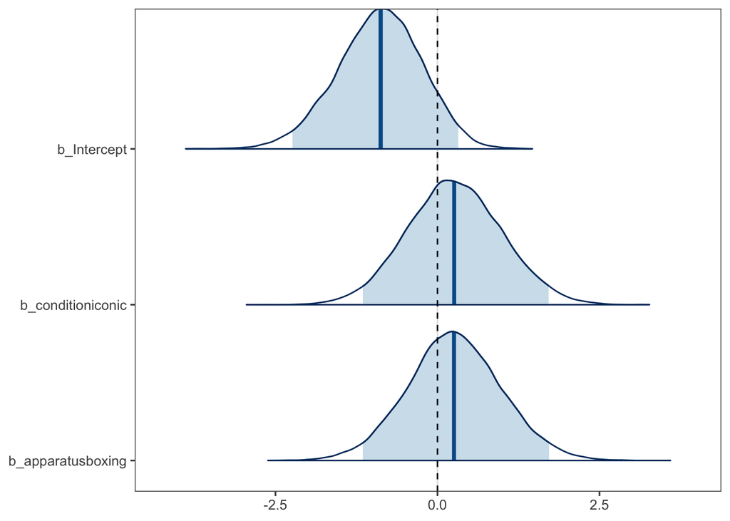

```r
bayesplot::mcmc_areas(as.array(m1_24),
                      pars = c("b_Intercept","b_conditioniconic", "b_apparatusboxing"),
                      prob = 0.95)+
  geom_vline(xintercept = 0, lty = 2, col = "black")+
  theme_few()
```

### 3-year-olds

#### WAIC

```r
waic_36mo <- brms::WAIC(m1_36,m2_36, compare = F)

weights_36mo <- model_weights(m1_36, m2_36, weights = "waic")

data_frame(
  model = c("model w/ condition","model w/o conditon"),
  WAIC = c(
    waic_36mo$loo$m1_36$estimates[3,1],
    waic_36mo$loo$m2_36$estimates[3,1]),
  SE = c(waic_36mo$loo$m1_36$estimates[3,2],
         waic_36mo$loo$m2_36$estimates[3,2]),
  weight = c(weights_36mo[1],
             weights_36mo[2]))%>%
  kable(digits = 2)
```

| model | WAIC | SE | weight |
| --- | --- | --- | --- |
| model w/ condition | 49.00 | 6.59 | 0.91 |
| model w/o conditon | 53.74 | 1.51 | 0.09 |

#### Summary for model including condition

```r
fixef(m1_36)%>%
  kable(digits = 2)
```

|  | Estimate | Est.Error | Q2.5 | Q97.5 |
| --- | --- | --- | --- | --- |
| Intercept | -0.77 | 0.66 | -2.11 | 0.49 |
| conditioniconic | 2.15 | 0.81 | 0.63 | 3.81 |
| apparatusboxing | 0.01 | 0.79 | -1.57 | 1.57 |

##### Density plots

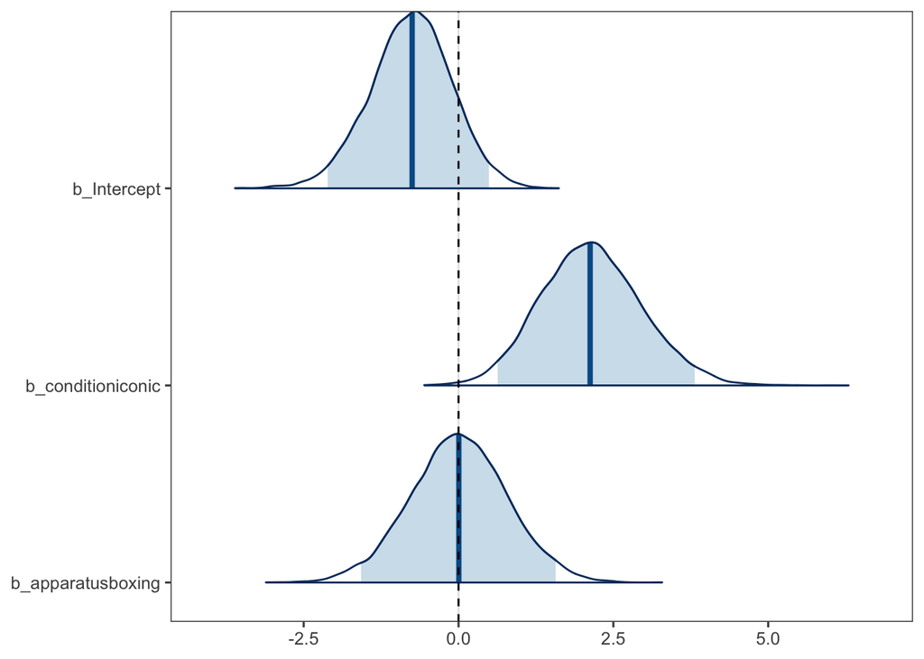

```r
bayesplot::mcmc_areas(as.array(m1_36),
                      pars = c("b_Intercept","b_conditioniconic", "b_apparatusboxing"),
                      prob = 0.95)+
  geom_vline(xintercept = 0, lty = 2, col = "black")+
  theme_few()
```

## Models for partial actions for 2-year-olds

### Figure S2: Plot for partial actions

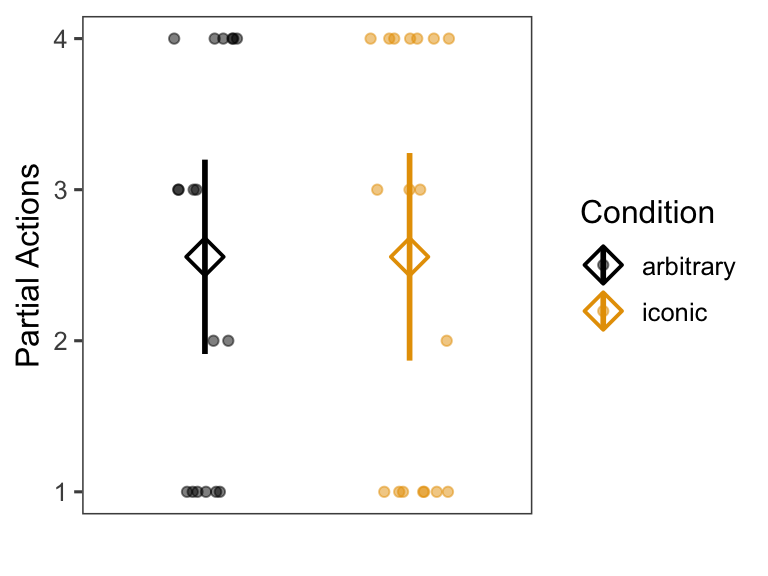

```r
# model including condition

# m1_24mopart = brm(sum_part_act ~
#           condition + apparatus,
#         data= data_24,
#         family = poisson(),
#         control = list(adapt_delta = 0.90),
#         sample_prior = F,
#         save_all_pars = T,
#         chains = 4,
#         cores = 4,
#         iter = 10000)%>%
#   saveRDS(.,"../saves/m1_24mopart.rds")

m1_24mopart <- readRDS("../saves/m1_24mopart.rds")

# model excluding condition

# m2_24mopart = brm(sum_part_act ~
#           apparatus,
#         data= data_24,
#         family = poisson(),
#         control = list(adapt_delta = 0.90),
#         sample_prior = F,
#         save_all_pars = T,
#         chains = 4,
#         cores = 4,
#         iter = 10000)%>%
#   saveRDS(.,"../saves/m2_24mopart.rds")

m2_24mopart <- readRDS("../saves/m2_24mopart.rds")
```

### WAIC

```r
# model selection based on WAIC

m24_waic_part <- brms::WAIC(m1_24mopart, m2_24mopart, compare = F)

weights_24mo_part <- model_weights(m1_24mopart, m2_24mopart, weights = "waic")

data_frame(
  model = c("model w/ condition","model w/o conditon"),
  WAIC = c(
    m24_waic_part$loo$m1_24mopart$estimates[3,1],
    m24_waic_part$loo$m2_24mopart$estimates[3,1]),
  SE = c(m24_waic_part$loo$m1_24mopart$estimates[3,2],
         m24_waic_part$loo$m2_24mopart$estimates[3,2]),
  weight = c(weights_24mo_part[1],
             weights_24mo_part[2]))%>%
  kable(digits = 2)
```

| model | WAIC | SE | weight |
| --- | --- | --- | --- |
| model w/ condition | 128.12 | 3.12 | 0.29 |
| model w/o conditon | 126.31 | 3.04 | 0.71 |

### Summary for model including condition

```r
fixef(m1_24mopart)%>%
  kable(digits = 2)
```

|  | Estimate | Est.Error | Q2.5 | Q97.5 |
| --- | --- | --- | --- | --- |
| Intercept | 0.85 | 0.19 | 0.47 | 1.20 |
| conditioniconic | 0.00 | 0.21 | -0.41 | 0.41 |
| apparatusboxing | 0.13 | 0.21 | -0.28 | 0.55 |

#### Density plots

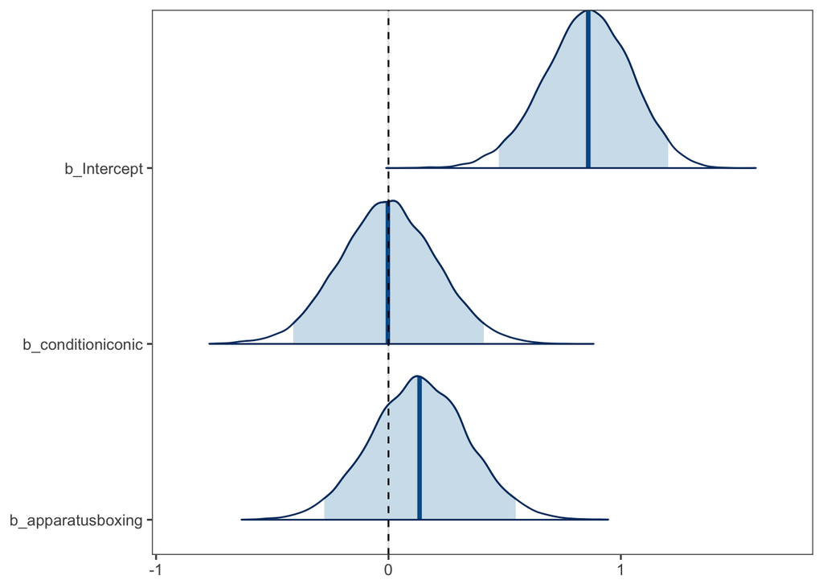

```r
bayesplot::mcmc_areas(as.array(m1_24mopart),
                      pars = c("b_Intercept","b_conditioniconic", "b_apparatusboxing"),
                      prob = 0.95)+
  geom_vline(xintercept = 0, lty = 2, col = "black")+
  theme_few()
```

# Study 1b: Replication with 3-year-old children using video demonstrations

## Methods

The apparatuses, gestures and basic procedure were the same as in study 1. Children were tested in a room in a child laboratory. Parents stayed outside the room. When entering the room, children found some marbles on the floor and were encouraged to put them on the marble run. Next, the experimenter drew their attention to the screen. The screen was embedded in a card board box to look less like a computer screen. The experimenter then initiated a contingent interaction between the child and the person shown on the screen (demonstrator). The goal was to make the child believe that the demonstrator was interacting with them. Videos were embedded in a PowerPoint presentation and the experimenter could start, stop and replay videos via a remote control in her pocket. After each interaction sequence, the the screen showed a red curtain. The videos that were used in test trials can be found in the associated online repository.

In the beginning, the demonstrator introduced herself and asked the child what they were doing. The experimenter encouraged the child to say that they were playing with a marble run. Then, the demonstrator said they also enjoy playing with the marble run. Next, the experimenter retrieved the first training box and told the child that the demonstrator also had a similar box. Then, the demonstrator pulled out the same training box and demonstrated how to open it. The same sequence was repeated for the second training box. Next, the experimenter placed the first test apparatus in front of the child and again encouraged the child to look to the screen. On the screen, the demonstrator retrieved the same test box, touched the two handles and then produced four iconic gestures (same as in study 1). The experimenter replayed the video showing the touching of the handles and the iconic gestures throughout the duration of the trial.

The trial ended when the child either openend the box or after 2 minutes passed. If the child did not open the box, the experimenter moved the box without showing how it was openend. The second trial began with the placing of the second box in front of the child and proceeded in the same way.

## Models for box opening

```r
data_36_rep <- data%>%
  filter(group == "36mo_replication")

# model with condition

# m1_36_rep = brm(solve ~
#           condition + apparatus + (1|subject),
#         data= data_36_rep,
#         family = bernoulli(),
#         control = list(adapt_delta = 0.90),
#         sample_prior = F,
#         chains = 4,
#         cores = 4,
#         save_all_pars = T,
#         iter = 10000)%>%
#   saveRDS(.,"../saves/m1_36_rep.rds")

m1_36_rep <- readRDS("../saves/m1_36_rep.rds")

# model without condition

# m2_36_rep = brm(solve ~
#           apparatus + (1|subject),
#         data= data_36_rep,
#         family = bernoulli(),
#         control = list(adapt_delta = 0.90),
#         sample_prior = F,
#         save_all_pars = T,
#         chains = 4,
#         cores = 4,
#         iter = 10000)%>%
#   saveRDS(.,"../saves/m2_36_rep.rds")

m2_36_rep <- readRDS("../saves/m2_36_rep.rds")
```

### WAIC

```r
waic_36mo_rep <- brms::WAIC(m1_36_rep,m2_36_rep, compare = F)

weights_36mo_rep <- model_weights(m1_36_rep, m2_36_rep, weights = "waic")

data_frame(
  model = c("model w/ condition","model w/o conditon"),
  WAIC = c(
    waic_36mo_rep$loos$m1_36_rep$estimates[3,1],
    waic_36mo_rep$loos$m2_36_rep$estimates[3,1]),
  SE = c(waic_36mo_rep$loos$m1_36_rep$estimates[3,2],
         waic_36mo_rep$loos$m2_36_rep$estimates[3,2]),
  weight = c(weights_36mo_rep[1],
             weights_36mo_rep[2]))%>%
  kable(digits = 2)
```

| model | WAIC | SE | weight |
| --- | --- | --- | --- |
| model w/ condition | 120.28 | 10.07 | 0.86 |
| model w/o conditon | 123.83 | 8.38 | 0.14 |

### Summary for model including condition

```r
fixef(m1_36_rep)%>%
  kable(digits = 2)
```

|  | Estimate | Est.Error | Q2.5 | Q97.5 |
| --- | --- | --- | --- | --- |
| Intercept | -1.14 | 0.72 | -2.79 | 0.10 |
| conditioniconic | 2.39 | 1.02 | 0.75 | 4.77 |
| apparatusboxing | -1.08 | 0.59 | -2.33 | 0.02 |

### Density plots

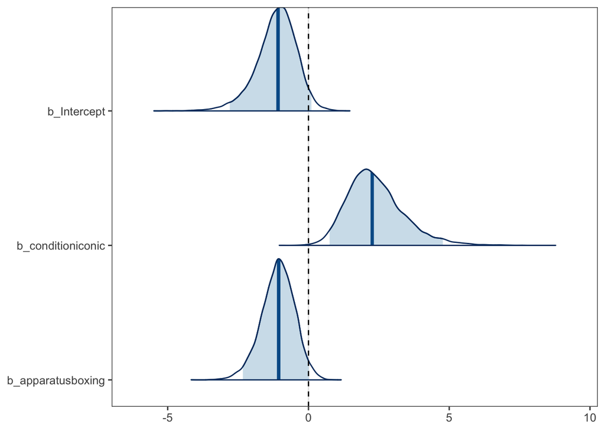

```r
bayesplot::mcmc_areas(as.array(m1_36_rep),
                      pars = c("b_Intercept","b_conditioniconic", "b_apparatusboxing"),
                      prob = 0.95)+
  geom_vline(xintercept = 0, lty = 2, col = "black")+
  theme_few()
```

# Study 2: Apes

## Models for box opening

```r
## subsetting the data
ape_data <- data %>%
  filter(group != "24mo",
         group != "36mo",
         group != "36mo_replication")

## model including condition

# m1ape = brm(solve ~
#           condition + apparatus,
#         data= ape_data,
#         family = bernoulli(),
#         control = list(adapt_delta = 0.90),
#         sample_prior = F,
#         save_all_pars = T,
#         iter = 10000)%>%
#   saveRDS(.,"../saves/m1ape.rds")

m1ape <- readRDS("../saves/m1ape.rds")

# model without condition

# m2ape = brm(solve ~
#           apparatus,
#         data= ape_data,
#         family = bernoulli(),
#         control = list(adapt_delta = 0.90),
#         sample_prior = F,
#         save_all_pars = T,
#         iter = 10000)%>%
#   saveRDS(.,"../saves/m2ape.rds")

m2ape <- readRDS("../saves/m2ape.rds")
```

### WAIC

```r
ape_waic <- brms::WAIC(m1ape,m2ape, compare = F)

ape_weights <- model_weights(m1ape, m2ape, weights = "waic")

data_frame(
  model = c("model w/ condition","model w/o conditon"),
  WAIC = c(
    ape_waic$loo$m1ape$estimates[3,1],
    ape_waic$loo$m2ape$estimates[3,1]),
  SE = c(ape_waic$loo$m1ape$estimates[3,2],
         ape_waic$loo$m2ape$estimates[3,2]),
  weight = c(ape_weights[1],
             ape_weights[2]))%>%
  kable(digits = 2)
```

| model | WAIC | SE | weight |
| --- | --- | --- | --- |
| model w/ condition | 33.35 | 11.43 | 0.16 |
| model w/o conditon | 30.07 | 10.07 | 0.84 |

### Summary for model including condition

```r
fixef(m1ape)%>%
  kable(digits = 2)
```

|  | Estimate | Est.Error | Q2.5 | Q97.5 |
| --- | --- | --- | --- | --- |
| Intercept | -2.42 | 1.04 | -4.72 | -0.63 |
| conditioniconic | -0.03 | 1.20 | -2.44 | 2.27 |
| apparatusboxing | 0.01 | 1.21 | -2.42 | 2.39 |

#### Density plots

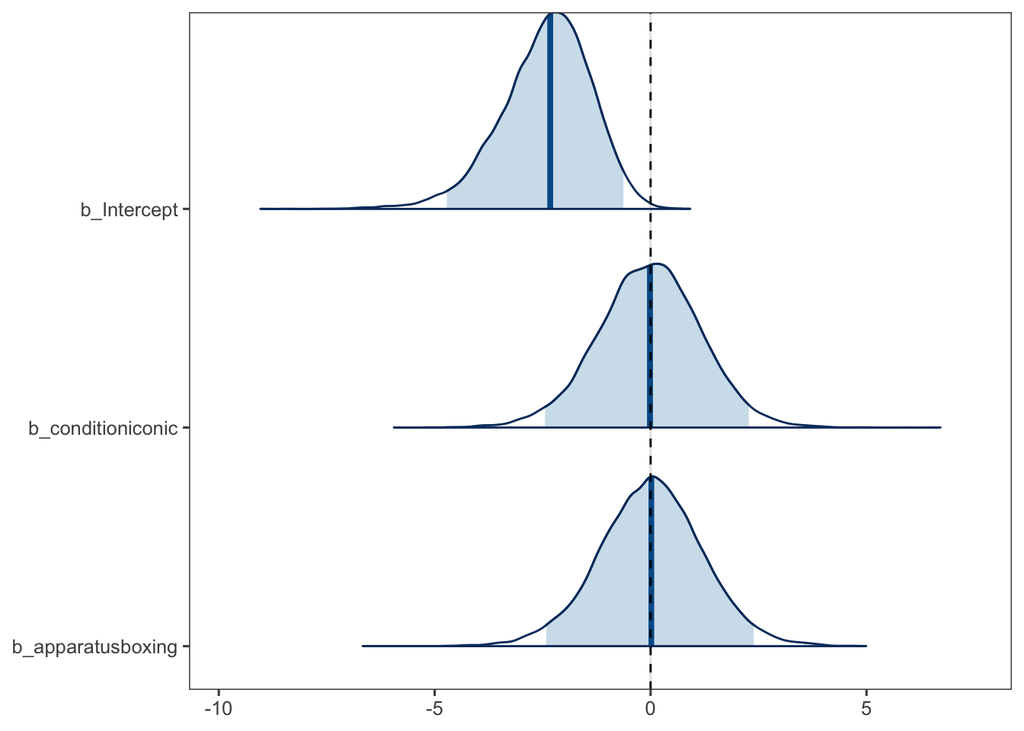

```r
bayesplot::mcmc_areas(as.array(m1ape),
                      pars = c("b_Intercept","b_conditioniconic", "b_apparatusboxing"),
                      prob = 0.95)+
  geom_vline(xintercept = 0, lty = 2, col = "black")+
  theme_few()
```

## Model for partial actions

### Figure S3:Plot for partial actions

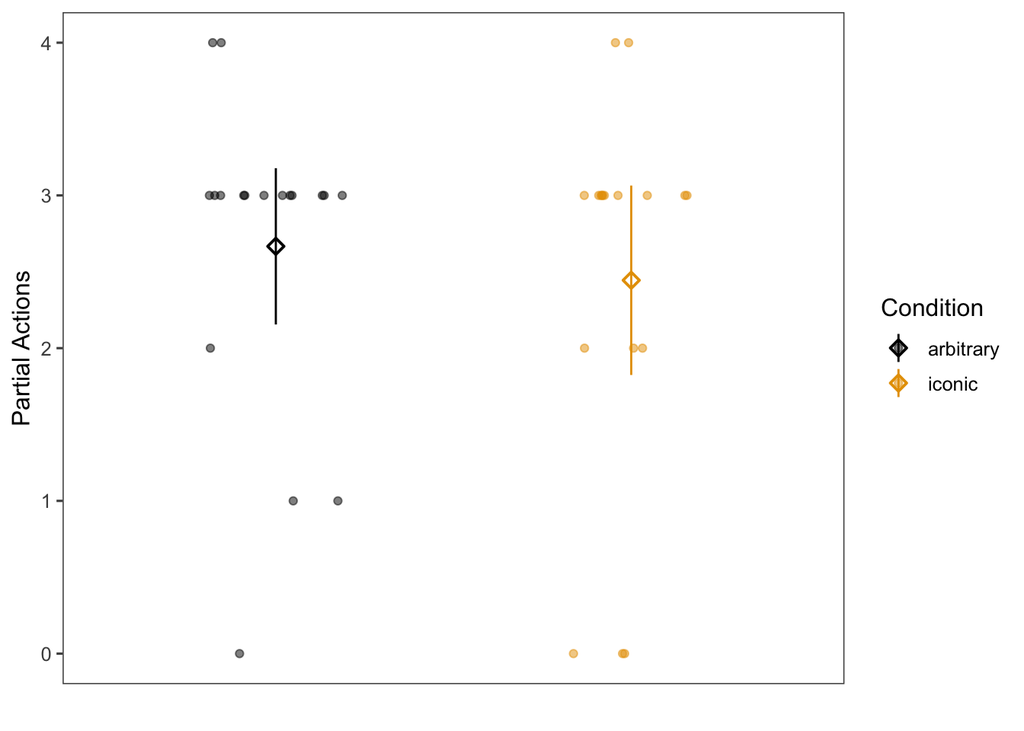

```r
## model including condition

# m1apepart = brm(sum_part_act ~
#           condition + apparatus,
#         data= ape_data,
#         family = poisson(),
#         control = list(adapt_delta = 0.90),
#         sample_prior = F,
#         save_all_pars = T,
#         iter = 10000)%>%
#   saveRDS(.,"../saves/m1apepart.rds")

m1apepart <- readRDS("../saves/m1apepart.rds")


# model without condition

# m2apepart = brm(sum_part_act ~
#           apparatus,
#         data= ape_data,
#         family = poisson(),
#         control = list(adapt_delta = 0.90),
#         sample_prior = F,
#         save_all_pars = T,
#         iter = 10000)%>%
#   saveRDS(.,"../saves/m2apepart.rds")

m2apepart <- readRDS("../saves/m2apepart.rds")
```

### WAIC

```r
ape_waic_part <- brms::WAIC(m1apepart,m2apepart, compare = F)

ape_weights_part <- model_weights(m1apepart, m1apepart, weights = "waic")

data_frame(
  model = c("model w/ condition","model w/o conditon"),
  WAIC = c(
    ape_waic_part$loo$m1apepart$estimates[3,1],
    ape_waic_part$loo$m2apepart$estimates[3,1]),
  SE = c(ape_waic_part$loo$m1apepart$estimates[3,2],
         ape_waic_part$loo$m2apepart$estimates[3,2]),
  weight = c(ape_weights_part[1],
             ape_weights_part[2]))%>%
  kable(digits = 2)
```

[output not shown]

```r
fixef(m1apepart)%>%
  kable(digits = 2)
```

|  | Estimate | Est.Error | Q2.5 | Q97.5 |
| --- | --- | --- | --- | --- |
| Intercept | 0.99 | 0.18 | 0.63 | 1.33 |
| conditioniconic | -0.09 | 0.21 | -0.51 | 0.32 |
| apparatusboxing | -0.04 | 0.21 | -0.46 | 0.38 |

#### Density plots

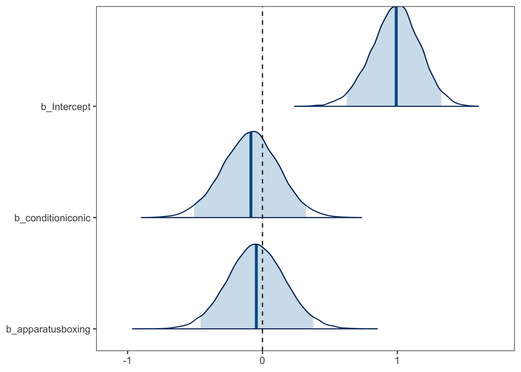

```r
bayesplot::mcmc_areas(as.array(m1apepart),
                      pars = c("b_Intercept","b_conditioniconic", "b_apparatusboxing"),
                      prob = 0.95)+
  geom_vline(xintercept = 0, lty = 2, col = "black")+
  theme_few()
```